# Lab 5 Count Regression

Author

Josh Budge

## Part 1. Configure your project and examine the data

### 1.2. Load the required packages

### 1.3. Load the dataset

The `NMES1988` dataset contains 4,406 respondents from the US National Medical Expenditure Survey. The outcome is the number of physician office visits. The predictors are number of chronic conditions, self-perceived health, gender, years of education, and private insurance coverage.

The reference groups are **average** for health, **male** for gender, and **no** for private insurance.

### 1.4. Explore the data

Table 1

Descriptive statistics for physician office visits

| N | Mean | Variance | Proportion with zero visits | Maximum |
| --- | --- | --- | --- | --- |
| 4,406 | 5.77 | 45.69 | 15.50% | 89 |

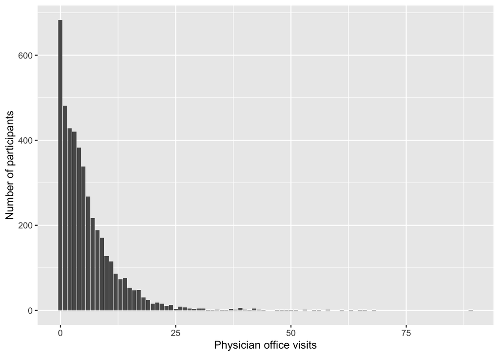

Figure 1: Distribution of physician office visits.

The outcome is a count of physician office visits, so it takes whole-number values starting at zero. About 15.5% of participants had no visits. Most people had few visits, but the chart has a long tail to the right, with a few high counts and a maximum of 89 visits. The variance (45.69) is much higher than the mean (5.77), so I’ll check whether the Poisson model can account for that much variation.

## Part 2. Specify competing count models

### 2.1. Why not a linear model?

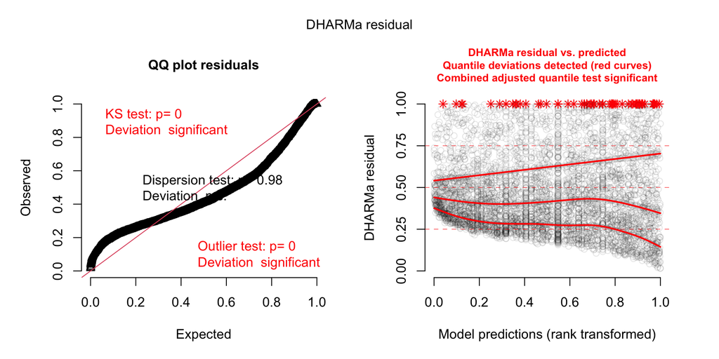

Figure 2: DHARMa residual diagnostics for the Gaussian model.

Both DHARMa plots suggest that the Gaussian model fits the visit counts poorly. In the Q–Q plot, the black points curve away from the red diagonal, so the residuals look different from what we would expect with a good fit. In the right panel, the middle red curve stays below the middle dashed line, suggesting that the model tends to predict too many visits. The outer curves spread farther apart at higher predicted visit counts, and the stars mark observed counts higher than all the simulations for those people. This linear model assumes that the expected count changes by a fixed amount for each extra unit of a numeric predictor. It also assumes bell-shaped errors with the same spread at every prediction and can simulate negative values. The real visit counts are whole numbers starting at zero, with many low counts and a few very high ones.

### 2.2. Specify three nested Poisson models

| Model | Predictors |
| --- | --- |
| M0 Null | Intercept only |
| M1 Chronic | Number of chronic conditions |
| M2 Full | Chronic conditions, health, gender, schooling, and private insurance |

### 2.3. Compare the fitted models

Table 2

Likelihood-ratio tests for the nested Poisson models

| Model | AIC | BIC | Log-likelihood | χ² | df | p-value |
| --- | --- | --- | --- | --- | --- | --- |
| M0: Null | 39,720.34 | 39,726.73 | −19,859.17 | — | — | — |
| M1: Chronic | 37,546.91 | 37,559.69 | −18,771.46 | 2,175.43 | 1 | <0.001 |
| M2: Full | 36,596.99 | 36,641.72 | −18,291.49 | 959.92 | 5 | <0.001 |

Each test compares the model in that row with the model above it.

The comparison of the chronic model with the null model gave χ² = 2175.43 with 1 degree of freedom (*p* <0.001). The comparison of the full model with the chronic model gave χ² = 959.92 with 5 degrees of freedom (*p* <0.001).

The likelihood-ratio tests showed that adding chronic conditions improved the fit over the null model. Adding health, gender, schooling, and insurance improved the fit further. I chose M2 as the Poisson model to carry forward because it had the highest (least negative) log-likelihood, so it fit the observed visit counts best of the three models. M2 also had the lowest AIC and BIC, so it was still preferred after accounting for the extra predictors. I’ll check how well M2 fits the data in Part 3.

## Part 3. Evaluate the Poisson model

### 3.1. Simulate residuals

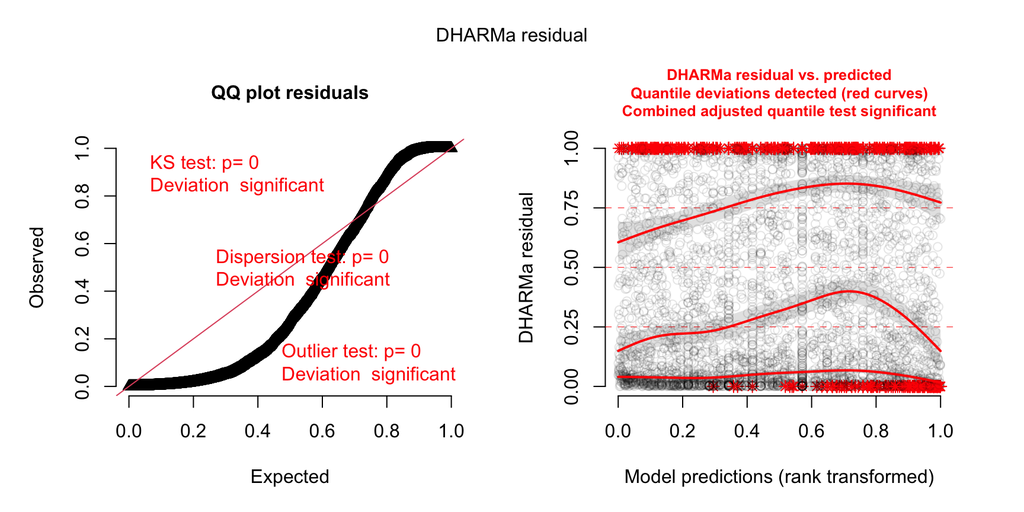

Figure 3: DHARMa residual diagnostics for the full Poisson model.

### 3.2. Test for overdispersion and excess zeros

The dispersion ratio was 7.25 (simulation *p* = 0). The ratio of observed to expected zeros was 14.91 (simulation *p* = 0). A simulation *p*-value displayed as zero means none of the 500 simulations was as extreme as the observed result.

### 3.3. Interpret the diagnostics

The Q–Q plot bends away from the diagonal, and residuals pile up near both ends of the right panel. This suggests the Poisson model struggles with very low and very high counts. The dispersion ratio was 7.25, and there were 14.91 times as many zeros as expected. Poisson assumes the variance equals the mean. With extra variation, its standard errors and *p*-values tend to be too small and its confidence intervals too narrow. I’ll check whether a negative binomial model’s extra spread can account for the zeros before adding a separate model for them.

## Part 4. Fit and evaluate a negative binomial model

### 4.1. Estimate the NB2 model

The negative binomial model uses the same predictors as the full Poisson model.

### 4.2. Compare the Poisson and NB2 models

The likelihood-ratio test comparing NB2 with the full Poisson model gave χ² = 12,129.08 with 1 degree of freedom (*p* <0.001).

NB2 fits significantly better than the full Poisson model. The single degree of freedom comes from the extra parameter NB2 uses to estimate the spread of the counts. In the DHARMa plots below, the Q–Q points are closer to the diagonal, and the dispersion test suggests NB2 captures the overall spread. The Poisson model underestimated that spread, so its standard errors were likely too small. The red curves still bend, and NB2 still predicts too few zeros.

### 4.3. Re-check the NB2 model with DHARMa

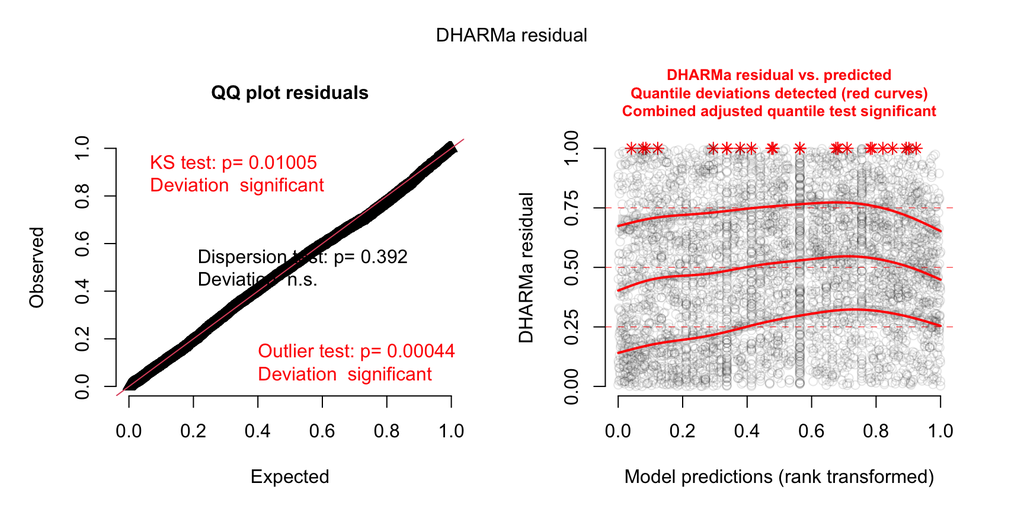

Figure 4: DHARMa residual diagnostics for the negative binomial model.

The dispersion ratio was 1.05 (simulation *p* = 0.392). The ratio of observed to expected zeros was 1.10 (simulation *p* = 0.004).

### 4.4. Visualize predicted counts

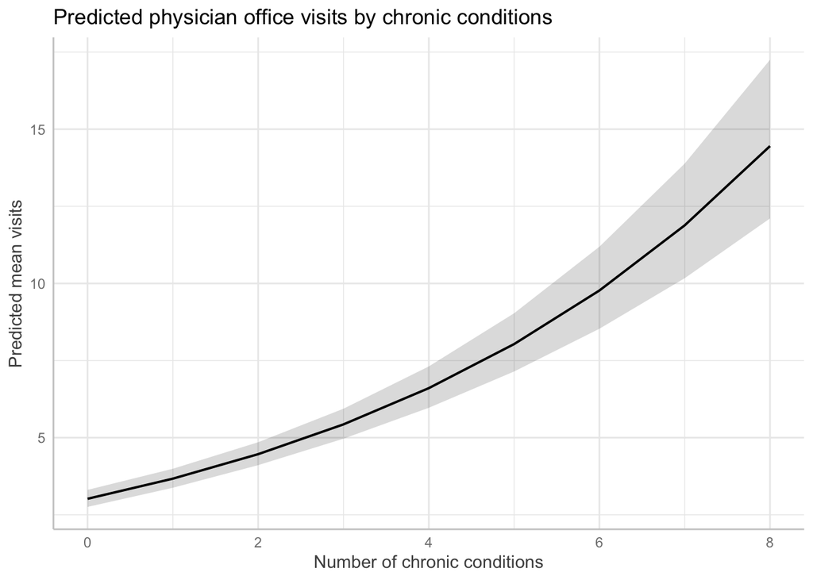

Figure 5: Predicted mean visits by number of chronic conditions. The shaded band shows the confidence interval for the mean.

The predictions hold years of schooling at its mean and health, gender, and insurance at their reference levels. With the log link, each extra chronic condition raises predicted visits by the same percentage. That adds more visits when the predicted count is already higher, so the line curves upward.

## Part 5. Decide whether the zeros need their own model

### 5.1. Compare models for the zeros

The NB2 model’s ratio of observed to expected zeros was 1.10 (simulation *p* = 0.004). Because NB2 still expected too few zeros, I fitted a zero-inflated NB model and a hurdle NB model, using the same predictors for the visit counts and for the zeros.

The likelihood-ratio test comparing ZINB with NB2 gave χ² = 143.14 with 7 degrees of freedom (*p* <0.001).

Table 3

Fit comparison for the negative binomial models

| Model | AIC | BIC |
| --- | --- | --- |
| NB2 | 24,469.91 | 24,521.03 |
| ZINB | 24,340.77 | 24,436.63 |
| Hurdle NB | 24,330.41 | 24,426.27 |

I used DHARMa to re-check the hurdle model, which had the lowest AIC and BIC.

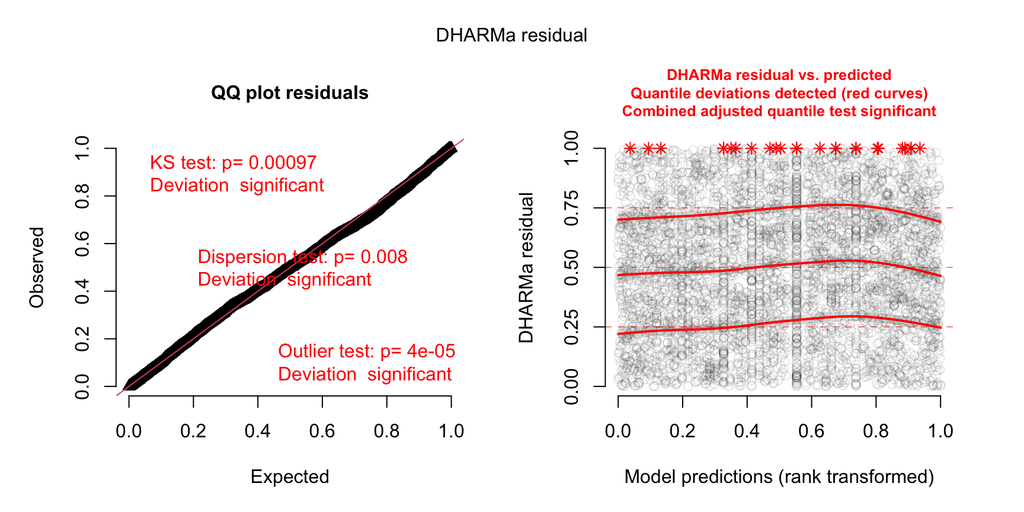

Figure 6: DHARMa residual diagnostics for the hurdle negative binomial model.

The hurdle model’s dispersion ratio was 1.15 (simulation *p* = 0.008). Its ratio of observed to expected zeros was 0.998 (simulation *p* = 0.984).

### 5.2. Justify the model choice

I would carry forward the hurdle model. The zero-inflated model fit better than NB2, and the hurdle model had the lowest AIC and BIC of all three. It expected about 684 people with no visits, close to the 683 we observed. It still slightly underestimates how much visit counts vary.

## Part 6. Test and probe an interaction

### 6.1. State the prediction

I expect the link between chronic conditions and doctor visits to be stronger for people with private insurance. Private insurance may make it easier to get follow-up care as health needs increase.

### 6.2. Fit the interaction model

The interaction is in the count part of the hurdle model. The zero part includes the same predictors as main effects.

### 6.3. Test the interaction

The likelihood-ratio test comparing the interaction model with the additive hurdle model gave χ² = 0.34 with 1 degree of freedom (*p* = 0.559).

The overall test asks whether adding the interaction improves model fit. The follow-up tests estimate the slope in each insurance group and compare the groups at low, average, and high numbers of chronic conditions.

### 6.4. Plot predicted counts

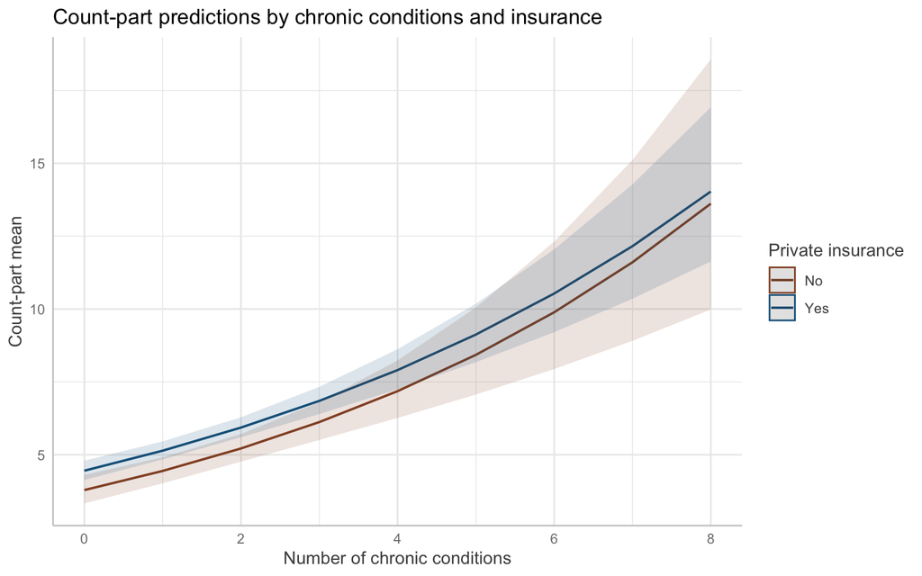

Figure 7: Count-part predictions by chronic conditions and private insurance. Shading shows confidence intervals.

The plot shows the count part’s mean on the visit scale before the adjustment for positive counts. Schooling is set to its mean, and health and gender are set to their reference levels.

### 6.5. Probe the interaction

#### Simple slopes by private insurance

```
 insurance chronic.trend     SE  df asymp.LCL asymp.UCL z.ratio p.value
 no                0.160 0.0247 Inf     0.111     0.208   6.462 <0.0001
 yes               0.143 0.0144 Inf     0.115     0.172   9.945 <0.0001

Results are averaged over the levels of: health, gender
Confidence level used: 0.95
 contrast estimate     SE  df z.ratio p.value
 no - yes   0.0164 0.0282 Inf   0.583  0.5597

Results are averaged over the levels of: health, gender
```

The slope comparison subtracts the slope for insured people from the slope for uninsured people. The model coefficient subtracts them in the opposite order. That flips the sign and gives the same standard error and Wald *p*-value. Both tests ask whether the two slopes differ.

#### Differences by private insurance at three levels of chronic conditions

```
chronic = 0.192:
 insurance response    SE  df asymp.LCL asymp.UCL
 no            4.04 0.249 Inf      3.58      4.55
 yes           4.73 0.172 Inf      4.40      5.08

chronic = 1.542:
 insurance response    SE  df asymp.LCL asymp.UCL
 no            5.01 0.225 Inf      4.58      5.47
 yes           5.74 0.167 Inf      5.42      6.07

chronic = 2.892:
 insurance response    SE  df asymp.LCL asymp.UCL
 no            6.21 0.309 Inf      5.64      6.85
 yes           6.96 0.234 Inf      6.52      7.44

Results are averaged over the levels of: health, gender
Confidence level used: 0.95
Intervals are back-transformed from the log scale
```

Both sets of predictions use the count part’s mean before the adjustment for positive counts. The plot uses the reference levels for health and gender, while `emmeans` averages over those groups. This can change the predicted means. The health and gender terms cancel when comparing insurance groups on the log scale, so the log contrasts agree.

### 6.6. Report the simple effects

Table 4

Simple effects of private insurance

| Chronic conditions | Contrast | Log contrast | SE | z | p |
| --- | --- | --- | --- | --- | --- |
| −1 SD (0.19) | no - yes | −0.158 | 0.065 | −2.450 | 0.014 |
| Mean (1.54) | no - yes | −0.136 | 0.045 | −3.055 | 0.002 |
| +1 SD (2.89) | no - yes | −0.114 | 0.052 | −2.199 | 0.028 |

Tests are computed on the log scale of the count part of the model.

## Part 7. Write up and discuss the findings

### 7.1. Results

Physician office visits averaged 5.77 (*s*² = 45.69), and 15.5% of participants had no visits. The full Poisson model had a dispersion ratio of 7.25 (simulation *p* = 0) and a zero ratio of 14.91 (simulation *p* = 0). NB2 fit better, χ²(1) = 12,129.08, *p* < .001. Its dispersion ratio was 1.05 (*p* = .392), and its zero ratio was 1.10 (*p* = .004). NB2 still expected too few zeros, so I chose the hurdle model, which had the lowest AIC and BIC and closely matched the observed number of zeros.

Holding the other predictors constant, more chronic conditions (*b* = 0.148, 95% CI [0.123, 0.172], *p* < .001), more schooling (*b* = 0.021, 95% CI [0.012, 0.030], *p* < .001), and private insurance (*b* = 0.130, 95% CI [0.045, 0.216], *p* = .003) were associated with more visits in the count part of the model. Compared with average health, poor health was associated with more visits (*b* = 0.383, 95% CI [0.287, 0.478], *p* < .001) and excellent health with fewer (*b* = -0.368, 95% CI [-0.501, -0.236], *p* < .001). The estimated count was higher for women than men, with an inconclusive difference (*b* = 0.056, 95% CI [-0.008, 0.121], *p* = .088). In the zero part, the odds of having no visits were lower for people with more chronic conditions (*b* = -0.558, 95% CI [-0.647, -0.470], *p* < .001), women (*b* = -0.401, 95% CI [-0.573, -0.230], *p* < .001), people with more schooling (*b* = -0.058, 95% CI [-0.082, -0.035], *p* < .001), and people with private insurance (*b* = -0.747, 95% CI [-0.944, -0.550], *p* < .001). Compared with average health, excellent health was associated with higher odds of no visits (*b* = 0.309, 95% CI [0.029, 0.588], *p* = .030), and the estimated lower odds for poor health were inconclusive (*b* = -0.050, 95% CI [-0.363, 0.263], *p* = .754).

Adding the chronic conditions × private insurance interaction gave χ²(1) = 0.34, *p* = .559. The chronic conditions slope was positive for people without private insurance (*b* = 0.160, 95% CI [0.111, 0.208], *p* < .001) and for those with it (*b* = 0.143, 95% CI [0.115, 0.172], *p* < .001). The log contrasts (no insurance minus insurance) were -0.158 (*p* = .014) at one SD below the mean, -0.136 (*p* = .002) at the mean, and -0.114 (*p* = .028) at one SD above the mean. The insured group had higher count estimates at all the values tested, with the largest gap on the log scale at the low value and little evidence that the slopes differed.

### 7.2. Discussion

Chronic conditions and private insurance were related to both whether people visited a doctor and how many visits they had. Among people who visited, those in poor health tended to have more visits, and those in excellent health tended to have fewer, compared with people in average health. The data come from a historical U.S. survey of older adults, and the results describe associations. Other factors, such as illness severity or access to care, may also matter. The hurdle model still underestimated how much visit counts varied.